# Studienarbeit Data Analytics

### Hypothese 3

> Betrachtet wird im Folgenden drei Messstationen in und um München (Innenstadt "Landshuter Allee", Stadtrand "Allach" und ländliches Münchner Gebiet "Andechs/Rothenfeld")  
> *\"Das Verhalten der NO2-Konzentration während des Lockdowns in Bayern verhält sich sowohl in ländlichen als auch in städtischen Gebieten in etwa gleich.\"*  
> **Zurück zur Aufgabestellung**

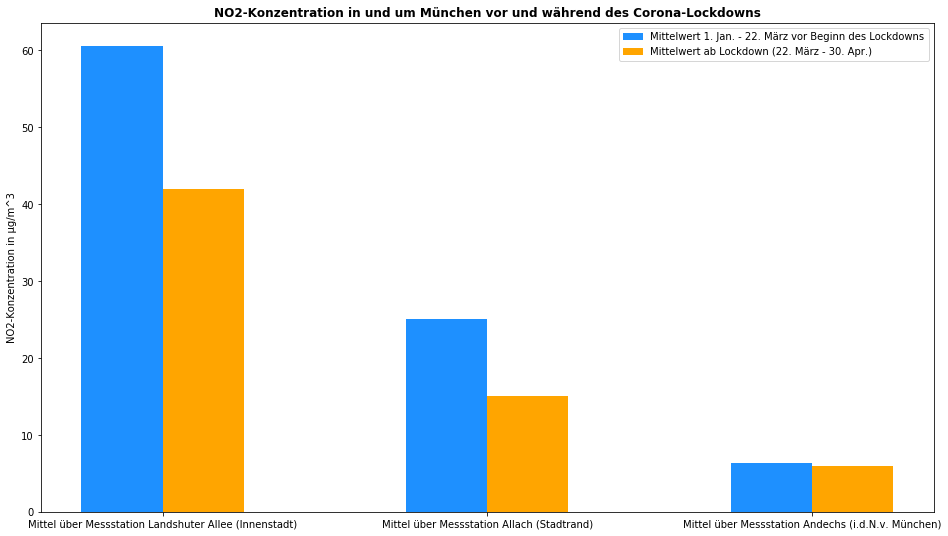

```python
# Vergleich München Innenstadt ("Landshuter Allee": ID 535), Stadtrand ("Allach": ID 609)
# und Ländliches Münchner Gebiet ("Andechs/Rothenfeld": ID 529)

# Durchschnittliche NO2-Werte im Zeitraum vor dem Lockdown berechnen
def get_avg_before(station_id):
    # Angegebene Stations-ID aus DataFrame filtern
    temp_station = data_cor.loc[data_cor['STATION_ID'] == station_id]

    # Jahr und Monat als Variable aus den Daten der Spalte "DT" anlegen
    day = temp_station['DT'].dt.day
    month = temp_station['DT'].dt.month

    # Filtern nach allen Werten im Zeitraum von Anfang Januar bis Ende März 2020 (Zeitraum vor dem Lockdown) und alle NO2-Werte im gegebenen Zeitraum berechnen
    return temp_station.loc[(month >= 1) & (month <= 3) & (day < 22)]['NO2'].mean()

# Durchschnittliche NO2-Werte im Zeitraum während des Lockdowns berechnen
def get_avg_lockdown(station_id):
    # Angegebene Stations-ID aus DataFrame filtern
    temp_station = data_cor.loc[data_cor['STATION_ID'] == station_id]

    # Jahr und Monat als Variable aus den Daten der Spalte "DT" anlegen
    day = temp_station['DT'].dt.day
    month = temp_station['DT'].dt.month

    # Filtern nach allen Werten im Zeitraum von 22. März bis Ende April 2020 (Genauer Zeitraum des Lockdowns) und alle NO2-Werte im gegebenen Zeitraum berechnen
    return temp_station.loc[((month >= 3) & (day >= 22)) & ((month <= 4))]['NO2'].mean()

#                                                         #
# =-- München Innenstadt ("Landshuter Allee": ID 535) --= #
#                                                         #

# Mittelwert über alle NO2-Werte im gegebenen Zeitraum
data_535_before_avg = get_avg_before(535)
data_535_lockdown_avg = get_avg_lockdown(535)


#                                              #
# =-- München Stadtrand ("Allach": ID 609) --= #
#                                              #

# Mittelwert über alle NO2-Werte im gegebenen Zeitraum
data_609_before_avg = get_avg_before(609)
data_609_lockdown_avg = get_avg_lockdown(609)


#                                                                   #
# =-- Ländliches Münchner Gebiet ("Andechs/Rothenfeld": ID 529) --= #
#                                                                   #

# Mittelwert über alle NO2-Werte im gegebenen Zeitraum
data_529_before_avg = get_avg_before(529)
data_529_lockdown_avg = get_avg_lockdown(529)

# NO2-Mittelwerte der (linken) Säulen (= vor dem Lockdown) in Liste speichern
bar_before = [data_535_before_avg, data_609_before_avg, data_529_before_avg]

# NO2-Mittelwerte der (rechten) Säulen (= während des Lockdowns) in Liste speichern
bar_after = [data_535_lockdown_avg, data_609_lockdown_avg, data_529_lockdown_avg]

# X-Achsen-Einteilung festlegen
x = np.arange(len(bar_before))

# Breite einer Säule, sodass zwei Säulen korrekt nebeneinander angezeigt werden können
bar_width = 0.25

plt.figure(figsize=(16, 9))

# Jeweils linke Säulen mit Werten vor Beginn des Lockdowns zeichnen
plt.bar(x, bar_before, width=bar_width, color='dodgerblue', label='Mittelwert 1. Jan. - 22. März vor Beginn des Lockdowns')

# Jeweils rechte Säulen mit Werten während des Lockdowns zeichnen
plt.bar(x + bar_width, bar_after, width=bar_width, color='orange', label='Mittelwert ab Lockdown (22. März - 30. Apr.)')

plt.legend()

plt.title('NO2-Konzentration in und um München vor und während des Corona-Lockdowns', fontdict=dict(fontweight='bold'))

plt.ylabel('NO2-Konzentration in µg/m^3')

# Beschriftung der gruppierten Säulen hinzufügen
plt.xticks(x + bar_width / 2, ['Mittel über Messstation Landshuter Allee (Innenstadt)', 'Mittel über Messstation Allach (Stadtrand)', 'Mittel über Messstation Andechs (i.d.N.v. München)'])

plt.show()
```

### Auswertung der Aufgabe 8c) / Hypothese 3

In diesem Säulendiagramm werden die durchschnittlichen NO2-Werte von insgesamt drei Münchner Messstationen vor und während des Lockdowns gegenüber gestellt. Die Messstationen sind so gewählt, dass sich eine Station in der Innenstadt, eine in einem Wohngebiet mit weniger Verkehrsaufkommen und eine in einem ländlichen Münchner Gebiet befindet. Hintergrundidee dieser Auswahl der Stationen ist, die Stärke der Auswirkung des Lockdowns auf die unterschiedlichen Gebiete einer Stadt herauszufinden. Beim Vergleich der drei gruppierten Säulen lässt sich auf den ersten Blick erkennen, dass die Auswirkungen auf die Luftqualität in der Innenstadt am größten ausfällt. Am Land hingegen ist der Rückgang der NO2-Konzentration nur auf dem Blatt zu erkennen, in der Realität merkt man vermutlich nichts von einer niedrigeren NO2-Konzentration in der Luft. Dass die Auswirkungen in der Stadt am höchsten sind lässt sich auch darauf zurückführen, dass durch die Ausgangsbeschränkung grundsätzlich weniger Verkehr in den Innenstädten ist: Die Menschen bleiben größenteils zu Hause und gehen nur für wirklich notwendige Besorgungen vor die Haustür.  
Ein weiterer Grund für den äußerst geringen Rückgang des NO2-Werts bei der ländlichen Messstation ist, dass die Leute auf dem Land sowieso mit dem Auto zur nächst größeren Stadt fahren müssen, um z. B. Lebensmittel besorgen zu können - in der Stadt ist dies nicht zwingend notwendig. Zudem ist zum einen dort grundsätzlich weniger Verkehr und zum anderen kann sich die Luft besser verteilen, sodass die NO2-Konzentration grundsätzlich geringer ist als in der Stadt.

## Zusammenfassung der Analyseergebnisse

> Das Dokument soll [...] eine abschließende Zusammenfassung der Analyseergebnisse und der gewonnenen Erkenntnisse enthalten.  
> **Zurück zur Gliederung**